# BA810 Team 7: Acovado Price Modeling

Ziqin Ma, Qiaoling Huang, Shihan Li, Chenran Peng, Elmira Ushirova

October 16, 2019

## Introduction

### Business Problem

## Dataset Debrief

### Data Source

### Descriptive Analysis

## Data Preparation

Before looking at the dataset, we first load the packages that will be used.

```r
options(stringsAsFactors = FALSE)

library(tidyverse)
library(lubridate)
library(ggplot2)
library(ggthemes)
library(fastDummies)
library(scales)
library(glmnet)
library(zoo)
library(ISLR)
library(leaps)
library(rpart)
library(rpart.plot)
library(tree)
library(randomForest)
library(gbm)
# Set the ggtheme beforehead for all plots
theme_set(theme_clean())
```

Then we load the original kaggle dataset and print a quick view of columns and data types.

```r
ds <- read_csv("avocado.csv")
glimpse(ds)
```

```
Observations: 18,249
Variables: 14
$ X1             <dbl> 0, 1, 2, 3, 4, 5, 6, 7, 8, 9, 10, 11, 12, 13, 14,…
$ Date           <date> 2015-12-27, 2015-12-20, 2015-12-13, 2015-12-06, …
$ AveragePrice   <dbl> 1.33, 1.35, 0.93, 1.08, 1.28, 1.26, 0.99, 0.98, 1…
$ `Total Volume` <dbl> 64236.62, 54876.98, 118220.22, 78992.15, 51039.60…
$ `4046`         <dbl> 1036.74, 674.28, 794.70, 1132.00, 941.48, 1184.27…
$ `4225`         <dbl> 54454.85, 44638.81, 109149.67, 71976.41, 43838.39…
$ `4770`         <dbl> 48.16, 58.33, 130.50, 72.58, 75.78, 43.61, 93.26,…
$ `Total Bags`   <dbl> 8696.87, 9505.56, 8145.35, 5811.16, 6183.95, 6683…
$ `Small Bags`   <dbl> 8603.62, 9408.07, 8042.21, 5677.40, 5986.26, 6556…
$ `Large Bags`   <dbl> 93.25, 97.49, 103.14, 133.76, 197.69, 127.44, 122…
$ `XLarge Bags`  <dbl> 0.00, 0.00, 0.00, 0.00, 0.00, 0.00, 0.00, 0.00, 0…
$ type           <chr> "conventional", "conventional", "conventional", "…
$ year           <dbl> 2015, 2015, 2015, 2015, 2015, 2015, 2015, 2015, 2…
$ region         <chr> "Albany", "Albany", "Albany", "Albany", "Albany",…
```

There are 14 columns in this dataset, and we will use `AveragePrice` as our prediction. `X1` gives a id for each observation, and we want to transfer that into row numbers for each row by adding 1. Most of the data types are `<dbl>`, and there are only 2 columns with character vectors, `type` and `region`. We will transfer them to dummy variables to train our models.

In the following code chunk, we took multiple steps to arrange the columns.

```r
# Switch the order of rows
ds <- ds %>%
  group_by(type, region) %>%
  select(X1, year, Date, type, region, everything()) %>%
  arrange(Date)

# Change `X1` to `ID`
colName <- names(ds)
colName[1] <- "ID"
names(ds) <- colName

# Assign distinct number id to each observation in `ID` column
ds$ID <- seq(nrow(ds))

# Extract month from `Date` column
ds$month <- month(ds$Date)
ds <- ds %>%
  select(ID, year, month, everything())
```

There are only 2 types of avocados recorded, conventional and organic. We decided to separate `type` column into `type_conventional` and `type_organic`.

```r
dsNew <- dummy_cols(ds, select_columns = "type") %>%
  select(ID, year, month, region, type_conventional, type_organic,
         everything(), -type)
```

The Product Look Up (PLU) codes are used by grocery retailers to make differnet product inventories. This dataset includes 3 PLU avocados, and we added a new column `other_PLU` to see the volume sold in products without PLU. The number is calculated by substracting PLU volumes from total volumes.

```r
dsNew$other_PLU <- dsNew$`Total Volume` - dsNew$`4046` - dsNew$`4225` - dsNew$`4770`

# Reorder the columes
dsNew <- dsNew %>%
  select(1:3, Date, everything())
```

Categorize `region` into US Areas

```r
uniqueRegion <- unique(dsNew$region)
uniqueRegion <- as.data.frame(uniqueRegion)
uniqueRegion$Area <- NA
uniqueRegion$Area[1] <- "NewEngland"
uniqueRegion$Area[2] <- "Southeast"
uniqueRegion$Area[3] <- "Mideast"
uniqueRegion$Area[4] <- "RockyMountain"
uniqueRegion$Area[5] <- "NewEngland"
uniqueRegion$Area[6] <- "Mideast"
uniqueRegion$Area[7] <- "FarWest"
uniqueRegion$Area[8] <- "Southeast"
uniqueRegion$Area[9] <- "GreatLakes"
uniqueRegion$Area[10] <- "GreatLakes"
uniqueRegion$Area[11] <- "GreatLakes"
uniqueRegion$Area[12] <- "Southwest"
uniqueRegion$Area[13] <- "RockyMountain"
uniqueRegion$Area[14] <- "GreatLakes"
uniqueRegion$Area[15] <- "GreatLakes"
uniqueRegion$Area[16] <- "GreatLakes"
uniqueRegion$Area[17] <- "Mideast"
uniqueRegion$Area[18] <- "NewEngland"
uniqueRegion$Area[19] <- "Southeast"
uniqueRegion$Area[20] <- "GreatLakes"
uniqueRegion$Area[21] <- "Southeast"
uniqueRegion$Area[22] <- "FarWest"
uniqueRegion$Area[23] <- "FarWest"
uniqueRegion$Area[24] <- "Southeast"
uniqueRegion$Area[25] <- "Southeast"
uniqueRegion$Area[26] <- "Southeast"
uniqueRegion$Area[27] <- "Southeast"
uniqueRegion$Area[28] <- "Southeast"
uniqueRegion$Area[29] <- "Mideast"
uniqueRegion$Area[30] <- "NewEngland"
uniqueRegion$Area[31] <- "NewEngland"
uniqueRegion$Area[32] <- "Southeast"
uniqueRegion$Area[33] <- "Mideast"
uniqueRegion$Area[34] <- "Southwest"
uniqueRegion$Area[35] <- "Mideast"
uniqueRegion$Area[36] <- "Plains"
uniqueRegion$Area[37] <- "FarWest"
uniqueRegion$Area[38] <- "Southeast"
uniqueRegion$Area[39] <- "Southeast"
uniqueRegion$Area[40] <- "Southeast"
uniqueRegion$Area[41] <- "FarWest"
uniqueRegion$Area[42] <- "FarWest"
uniqueRegion$Area[43] <- "FarWest"
uniqueRegion$Area[44] <- "FarWest"
uniqueRegion$Area[45] <- "Southeast"
uniqueRegion$Area[46] <- "Southeast"
uniqueRegion$Area[47] <- "Southeast"
uniqueRegion$Area[48] <- "FarWest"
uniqueRegion$Area[49] <- "Plains"
uniqueRegion$Area[50] <- "Mideast"
uniqueRegion$Area[51] <- "Southeast"
uniqueRegion$Area[52] <- "TotalUS"
uniqueRegion$Area[53] <- "FarWest"
uniqueRegion$Area[54] <- "Southwest"
names(uniqueRegion)[1] <- "region"

avo <- dsNew %>%
  left_join(uniqueRegion, by = "region") %>%
  select(1:5, Area, everything())


avo <- dummy_cols(avo, select_columns = "Area")
```

Rename Column Names

```r
colnames(avo)
```

```
 [1] "ID"                 "year"               "month"
 [4] "Date"               "region"             "Area"
 [7] "type_conventional"  "type_organic"       "AveragePrice"
[10] "Total Volume"       "4046"               "4225"
[13] "4770"               "Total Bags"         "Small Bags"
[16] "Large Bags"         "XLarge Bags"        "other_PLU"
[19] "Area_NewEngland"    "Area_Southeast"     "Area_Mideast"
[22] "Area_RockyMountain" "Area_FarWest"       "Area_GreatLakes"
[25] "Area_Southwest"     "Area_Plains"        "Area_TotalUS"
```

```r
names(avo)[10] <- "TotalVolume"
names(avo)[14] <- "TotalBags"
names(avo)[15] <- "SmallBags"
names(avo)[16] <- "LargeBags"
names(avo)[17] <- "XLargeBags"
names(avo)[11] <- "PLU4046"
names(avo)[12] <- "PLU4225"
names(avo)[13] <- "PLU4770"
```

## Create Train and Test Datasets

```r
set.seed(1234)
avo_train <- avo %>% filter(as.Date(Date) < "2017-03-01")
avo_train %>%
  filter(year == 2017, month == 2)
```

| ID | year | month | Date | region | Area | type_conventional | type_organic | AveragePrice | TotalVolume | PLU4046 | PLU4225 | PLU4770 | TotalBags | SmallBags | LargeBags | XLargeBags | other_PLU | Area_NewEngland | Area_Southeast | Area_Mideast | Area_RockyMountain | Area_FarWest | Area_GreatLakes | Area_Southwest | Area_Plains | Area_TotalUS |
| --- | --- | --- | --- | --- | --- | --- | --- | --- | --- | --- | --- | --- | --- | --- | --- | --- | --- | --- | --- | --- | --- | --- | --- | --- | --- | --- |
| 11772 | 2017 | 2 | 2017-02-05 | Albany | NewEngland | 1 | 0 | 1.49 | 183549.08 | 5666.60 | 165530.03 | 2119.02 | 10233.43 | 10047.32 | 186.11 | 0.00 | 10233.43 | 1 | 0 | 0 | 0 | 0 | 0 | 0 | 0 | 0 |
| 11773 | 2017 | 2 | 2017-02-05 | Atlanta | Southeast | 1 | 0 | 0.83 | 888094.87 | 442152.50 | 167181.75 | 412.85 | 278347.77 | 180392.30 | 97837.41 | 118.06 | 278347.77 | 0 | 1 | 0 | 0 | 0 | 0 | 0 | 0 | 0 |
| 11774 | 2017 | 2 | 2017-02-05 | BaltimoreWashington | Mideast | 1 | 0 | 1.09 | 1170444.52 | 174325.38 | 770463.22 | 29352.66 | 196303.26 | 187362.83 | 6286.24 | 2654.19 | 196303.26 | 0 | 0 | 1 | 0 | 0 | 0 | 0 | 0 | 0 |
| 11775 | 2017 | 2 | 2017-02-05 | Boise | RockyMountain | 1 | 0 | 0.90 | 136090.67 | 36808.59 | 11333.87 | 23346.13 | 64602.08 | 61439.09 | 3116.04 | 46.95 | 64602.08 | 0 | 0 | 0 | 1 | 0 | 0 | 0 | 0 | 0 |
| 11776 | 2017 | 2 | 2017-02-05 | Boston | NewEngland | 1 | 0 | 1.19 | 772110.18 | 50889.62 | 594522.97 | 7080.99 | 119616.60 | 119075.00 | 541.60 | 0.00 | 119616.60 | 1 | 0 | 0 | 0 | 0 | 0 | 0 | 0 | 0 |
| 11777 | 2017 | 2 | 2017-02-05 | BuffaloRochester | Mideast | 1 | 0 | 1.40 | 188582.23 | 1561.11 | 97167.09 | 116.10 | 89737.93 | 89664.64 | 73.29 | 0.00 | 89737.93 | 0 | 0 | 1 | 0 | 0 | 0 | 0 | 0 | 0 |
| 11778 | 2017 | 2 | 2017-02-05 | California | FarWest | 1 | 0 | 0.67 | 11213596.29 | 3986429.59 | 3550403.07 | 214137.93 | 3462625.70 | 3403581.49 | 7838.83 | 51205.38 | 3462625.70 | 0 | 0 | 0 | 0 | 1 | 0 | 0 | 0 | 0 |
| 11779 | 2017 | 2 | 2017-02-05 | Charlotte | Southeast | 1 | 0 | 0.95 | 359702.04 | 95176.35 | 172311.19 | 21721.89 | 70492.61 | 56412.26 | 13627.57 | 452.78 | 70492.61 | 0 | 1 | 0 | 0 | 0 | 0 | 0 | 0 | 0 |
| 11780 | 2017 | 2 | 2017-02-05 | Chicago | GreatLakes | 1 | 0 | 0.70 | 1621253.97 | 378806.26 | 912672.33 | 224554.50 | 105220.88 | 94444.33 | 1936.79 | 8839.76 | 105220.88 | 0 | 0 | 0 | 0 | 0 | 1 | 0 | 0 | 0 |
| 11781 | 2017 | 2 | 2017-02-05 | CincinnatiDayton | GreatLakes | 1 | 0 | 0.65 | 411450.85 | 3229.39 | 181550.84 | 3016.89 | 223653.73 | 35158.21 | 188488.10 | 7.42 | 223653.73 | 0 | 0 | 0 | 0 | 0 | 1 | 0 | 0 | 0 |

[output cut: 422 more lines]

```r
avo_test <- avo %>% filter(as.Date(Date) >= "2017-03-01")
avo_test %>%
  filter(year == 2018, month == 3)
```

| ID | year | month | Date | region | Area | type_conventional | type_organic | AveragePrice | TotalVolume | PLU4046 | PLU4225 | PLU4770 | TotalBags | SmallBags | LargeBags | XLargeBags | other_PLU | Area_NewEngland | Area_Southeast | Area_Mideast | Area_RockyMountain | Area_FarWest | Area_GreatLakes | Area_Southwest | Area_Plains | Area_TotalUS |
| --- | --- | --- | --- | --- | --- | --- | --- | --- | --- | --- | --- | --- | --- | --- | --- | --- | --- | --- | --- | --- | --- | --- | --- | --- | --- | --- |
| 17818 | 2018 | 3 | 2018-03-04 | Albany | NewEngland | 1 | 0 | 1.08 | 139520.60 | 12002.12 | 105069.57 | 95.62 | 22353.29 | 16128.51 | 5941.45 | 283.33 | 22353.29 | 1 | 0 | 0 | 0 | 0 | 0 | 0 | 0 | 0 |
| 17819 | 2018 | 3 | 2018-03-04 | Atlanta | Southeast | 1 | 0 | 1.08 | 594551.60 | 272245.24 | 37136.05 | 1763.52 | 283406.79 | 178019.66 | 103016.02 | 2371.11 | 283406.79 | 0 | 1 | 0 | 0 | 0 | 0 | 0 | 0 | 0 |
| 17820 | 2018 | 3 | 2018-03-04 | BaltimoreWashington | Mideast | 1 | 0 | 1.25 | 988572.63 | 102687.68 | 619501.22 | 5269.13 | 261114.60 | 256822.62 | 4225.31 | 66.67 | 261114.60 | 0 | 0 | 1 | 0 | 0 | 0 | 0 | 0 | 0 |
| 17821 | 2018 | 3 | 2018-03-04 | Boise | RockyMountain | 1 | 0 | 1.22 | 91070.80 | 44454.46 | 1835.89 | 10101.52 | 34678.93 | 26585.16 | 8061.36 | 32.41 | 34678.93 | 0 | 0 | 0 | 1 | 0 | 0 | 0 | 0 | 0 |
| 17822 | 2018 | 3 | 2018-03-04 | Boston | NewEngland | 1 | 0 | 1.19 | 785188.72 | 20384.08 | 645988.55 | 1884.67 | 116931.42 | 88147.57 | 27442.74 | 1341.11 | 116931.42 | 1 | 0 | 0 | 0 | 0 | 0 | 0 | 0 | 0 |
| 17823 | 2018 | 3 | 2018-03-04 | BuffaloRochester | Mideast | 1 | 0 | 1.19 | 168190.37 | 13533.32 | 75344.69 | 67.47 | 79244.89 | 23485.14 | 55219.75 | 540.00 | 79244.89 | 0 | 0 | 1 | 0 | 0 | 0 | 0 | 0 | 0 |
| 17824 | 2018 | 3 | 2018-03-04 | California | FarWest | 1 | 0 | 1.13 | 6295529.61 | 2380723.98 | 1676629.99 | 116796.74 | 2121378.90 | 1992549.07 | 47126.97 | 81702.86 | 2121378.90 | 0 | 0 | 0 | 0 | 1 | 0 | 0 | 0 | 0 |
| 17825 | 2018 | 3 | 2018-03-04 | Charlotte | Southeast | 1 | 0 | 1.32 | 259060.74 | 67459.59 | 80515.46 | 6005.97 | 105079.72 | 97703.43 | 7376.29 | 0.00 | 105079.72 | 0 | 1 | 0 | 0 | 0 | 0 | 0 | 0 | 0 |
| 17826 | 2018 | 3 | 2018-03-04 | Chicago | GreatLakes | 1 | 0 | 1.53 | 820728.47 | 109595.38 | 465039.55 | 104755.22 | 141338.32 | 97377.72 | 42517.93 | 1442.67 | 141338.32 | 0 | 0 | 0 | 0 | 0 | 1 | 0 | 0 | 0 |
| 17827 | 2018 | 3 | 2018-03-04 | CincinnatiDayton | GreatLakes | 1 | 0 | 1.02 | 265942.15 | 69312.67 | 20912.27 | 9651.63 | 166065.58 | 146627.38 | 14918.25 | 4519.95 | 166065.58 | 0 | 0 | 0 | 0 | 0 | 1 | 0 | 0 | 0 |

[output cut: 422 more lines]

```r
NA
NA
```

Base model

```r
f1 <- as.formula(AveragePrice ~ month+type_conventional + type_organic + TotalVolume +
                   PLU4046 + PLU4770 + PLU4225 + SmallBags + LargeBags + XLargeBags +
                   + Area_NewEngland + Area_Southeast
                 + Area_Mideast + Area_RockyMountain
                 + Area_FarWest + Area_GreatLakes
                 + Area_Southwest + Area_Plains + Area_TotalUS)

x1_train <- model.matrix(f1,avo_train)[,-1]
y1_train <- avo_train$AveragePrice
x1_test <- model.matrix(f1,avo_test)[,-1]
y1_test <- avo_test$AveragePrice
x1_avo <- model.matrix(f1, avo)[,-1]
```

## Modeling

### Linear Regression

```r
fit.lm <- lm(f1, avo_train)
fit.lm

y.train <- avo_train$AveragePrice
y.test <- avo_test$AveragePrice
yhat.train.lm <- predict(fit.lm)
mse.train.lm <- mean((y.train - yhat.train.lm)^2)
yhat.test.lm <- predict(fit.lm, avo_test)
mse.test.lm <- mean((y.test - yhat.test.lm)^2)
mse.train.lm
mse.test.lm

coef(fit.lm)
plot(fit.lm)
```

### Forward Selection

```r
avo1 <- avo
avo1$ID <- NULL
avo1$year<-NULL
avo1$Date<-NULL
avo1$region<-NULL
avo1$Area<-NULL
avo1$AveragePrice<-NULL
xnames <- colnames(avo1)
xnames <- xnames[!xnames %in% c("type_conventional","type_organic", "TotalVolume", "PLU4046", "PLU4770", "PLU4225","SmallBags", "LargeBags","XLargeBags","Area_NewEngland","Area_Southeast","Area_Mideast","Area_RockyMountain","Area_FarWest","Area_GreatLakes","Area_Southwest","Area_Plains + Area_TotalUS")]
fit_fw <- lm(AveragePrice ~ 1, data = avo_train)
yhat_train <- predict(fit_fw, avo_train)
mse_train <- mean((avo_train$AveragePrice - yhat_train) ^ 2)
yhat_test <- predict(fit_fw, avo_test)
mse_test <- mean((avo_test$AveragePrice - yhat_test) ^ 2)

log_fw <-
tibble(
xname = "intercept",
model = deparse(fit_fw$call),
mse_train = mse_train,
mse_test = mse_test
)

best_mse_train <- NA
best_mse_test <- NA
best_fit_fw <- NA
best_xname <- NA
for (xname in xnames) {
# take a moment to examine and understand the following line
fit_fw_tmp <- update(fit_fw, as.formula(paste0(" ~ ", xname)))
# compute MSE train
yhat_train_tmp <- predict(fit_fw_tmp, avo_train)
mse_train_tmp <- mean((avo_train$AveragePrice - yhat_train_tmp) ^ 2)
# compute MSE test
yhat_test_tmp <- predict(fit_fw_tmp, avo_test)
mse_test_tmp <- mean((avo_test$AveragePrice - yhat_test_tmp) ^ 2)
# if this is the first predictor to be examined,
# or if this predictors yields a lower MSE that the current
# best, then store this predictor as the current best predictor
if (is.na(best_mse_test) | mse_test_tmp < best_mse_test) {
best_xname <- xname
best_fit_fw <- fit_fw_tmp
best_mse_train <- mse_train_tmp
best_mse_test <- mse_test_tmp
}
}
best_mse_train
best_mse_test
```

```r
log_fw <-
log_fw %>% add_row(
xname = best_xname,
model = paste0(deparse(best_fit_fw$call), collapse = ""),
mse_train = best_mse_train,
mse_test = best_mse_test
)

log_fw

# here is a complete solution
xnames<- colnames(avo1)
xnames <- xnames[!xnames %in% c("type_conventional","type_organic", "TotalVolume", "PLU4046", "PLU4770", "PLU4225","SmallBags", "LargeBags","XLargeBags","Area_NewEngland","Area_Southeast","Area_Mideast","Area_RockyMountain","Area_FarWest","Area_GreatLakes","Area_Southwest","Area_Plains + Area_TotalUS")]
fit_fw <- lm(AveragePrice ~ 1, data = avo_train)
yhat_train <- predict(fit_fw, avo_train)
yhat_test <- predict(fit_fw, avo_test)
mse_train <- mean((avo_train$AveragePrice - yhat_train)^2)
mse_test <- mean((avo_test$AveragePrice - yhat_test)^2)
xname <- "intercept"

log_fw <-
tibble(
xname = xname,
model = paste0(deparse(fit_fw$call), collapse = ""),
mse_train = mse_train,
mse_test = mse_test
)
while (length(xnames) > 0) {
best_mse_train <- NA
best_mse_test <- NA
best_fit_fw <- NA
best_xname <- NA
# select the next best predictor
for (xname in xnames) {
# take a moment to examine and understand the following line
fit_fw_tmp <- update(fit_fw, as.formula(paste0(". ~ . + ", xname)))
# compute MSE train
yhat_train_tmp <- predict(fit_fw_tmp, avo_train)
mse_train_tmp <- mean((avo_train$AveragePrice - yhat_train_tmp) ^ 2)
# compute MSE test
yhat_test_tmp <- predict(fit_fw_tmp, avo_test)
mse_test_tmp <- mean((avo_test$AveragePrice - yhat_test_tmp) ^ 2)

# if this is the first predictor to be examined,
# or if this predictors yields a lower MSE that the current
# best, then store this predictor as the current best predictor
if (is.na(best_mse_test) | mse_test_tmp < best_mse_test) {
best_xname <- xname
best_fit_fw <- fit_fw_tmp
best_mse_train <- mse_train_tmp
best_mse_test <- mse_test_tmp
}
}
log_fw <-
log_fw %>% add_row(
xname = best_xname,
model = paste0(deparse(best_fit_fw$call), collapse = ""),
mse_train = best_mse_train,
mse_test = best_mse_test
)
# adopt the best model for the next iteration
fit_fw <- best_fit_fw
# remove the current best predictor from the list of predictors
xnames <- xnames[xnames!=best_xname]
}
```

```r
ggplot(log_fw, aes(seq_along(xname), mse_test)) +
geom_point() +
geom_line() +
geom_point(aes(y=mse_train), color="#AA471F") +
geom_line(aes(y=mse_train), color="#AA471F") +
scale_x_continuous("Variables", labels = log_fw$xname, breaks = seq_along(log_fw$xname)) +
scale_y_continuous("MSE test") +
theme(axis.text.x = element_text(angle = 45, hjust = 1))
```

```r
fw<- as.formula(AveragePrice ~ month + TotalBags + Area_TotalUS + Area_Plains + other_PLU)
fit.fw<-lm(fw, data = avo_train)
```

```r
## calculate the yhat price for the avo dataset
yhat_avo_fw <- predict(fit.fw, avo)
df1_fw<-avo %>%
  select(Date, AveragePrice)
df2_fw<-cbind(df1_fw, yhat_avo_fw)
colnames(df2_fw)
names(df2_fw)[3]<-"AveragePrice_hat"
## Plot the actual average price and the predictive average price
plot1_fw <- df2_fw %>%
  group_by(Date) %>%
  summarize(
    MeanAvg=mean(AveragePrice),
    MeanAvg_hat=mean(AveragePrice_hat))%>%
    ggplot()+
    geom_line(aes(Date, MeanAvg),color = "#356211")+
    geom_line(aes(Date, MeanAvg_hat), color = "#cda989")+
    theme_classic()

plot1_fw + geom_vline(aes(xintercept = as.numeric(Date[113])),
                   linetype = "dashed", size = 1,
                   color = "#AA471F")
```

### Backward Selection

- Using `f1` formula to match average price with all predictors in order to see the best model which contains a giving number of predictors.

```r
regfit.bwd = regsubsets(f1, data = avo_train, nvmax = 19, method = "backward")
```

```
2  linear dependencies found
```

```
Reordering variables and trying again:
```

```
number of items to replace is not a multiple of replacement length
```

```r
summary(regfit.bwd)
```

```
Subset selection object
Call: regsubsets.formula(f1, data = avo_train, nvmax = 19, method = "backward")
19 Variables  (and intercept)
                   Forced in Forced out
month                  FALSE      FALSE
type_conventional      FALSE      FALSE
TotalVolume            FALSE      FALSE
PLU4046                FALSE      FALSE
PLU4770                FALSE      FALSE
PLU4225                FALSE      FALSE
SmallBags              FALSE      FALSE
LargeBags              FALSE      FALSE
XLargeBags             FALSE      FALSE
Area_NewEngland        FALSE      FALSE
Area_Southeast         FALSE      FALSE
```

[output cut: 82 more lines]

Calculate the yhat and MSE for train and test dataset, the test MSE is way to large for the model including all the predictors.

```r
sub_model<-lm(f1, data = avo_train)
yhat_train_stepwise <- predict(sub_model, avo_train)
```

```
prediction from a rank-deficient fit may be misleading
```

```r
MSE_train_stepwise <- mean((avo_train$AveragePrice - yhat_train_stepwise)^2)
MSE_train_stepwise
```

```
[1] 0.06454066
```

```r
yhat_test_stepwise <- predict(sub_model, avo_test)
```

```
prediction from a rank-deficient fit may be misleading
```

```r
MSE_test_stepwise <- mean((avo_test$AveragePrice - yhat_test_stepwise)^2)
MSE_test_stepwise
```

```
[1] 387.6258
```

Based on the result of summary, the best fit model contains everything except “Area_TotalUS”, “type_organic”. So we excluded these two predictors to create a new formula to train the model.

```r
f1_1 <- as.formula(AveragePrice ~ month + type_conventional + TotalVolume +
                      PLU4046 + PLU4770 + PLU4225 + SmallBags + LargeBags + XLargeBags +
                      + Area_NewEngland + Area_Southeast
                    + Area_Mideast + Area_RockyMountain
                    + Area_FarWest + Area_GreatLakes
                    + Area_Southwest
                    + Area_Plains)
regfit.bwd1 = regsubsets(f1_1, data = avo_train, nvmax = 19, method = "backward")
summary(regfit.bwd1)
```

```
Subset selection object
Call: regsubsets.formula(f1_1, data = avo_train, nvmax = 19, method = "backward")
17 Variables  (and intercept)
                   Forced in Forced out
month                  FALSE      FALSE
type_conventional      FALSE      FALSE
TotalVolume            FALSE      FALSE
PLU4046                FALSE      FALSE
PLU4770                FALSE      FALSE
PLU4225                FALSE      FALSE
SmallBags              FALSE      FALSE
LargeBags              FALSE      FALSE
XLargeBags             FALSE      FALSE
Area_NewEngland        FALSE      FALSE
Area_Southeast         FALSE      FALSE
```

[output cut: 80 more lines]

```r
sub_model1<-lm(f1_1, data = avo_train)
yhat_train_stepwise1 <- predict(sub_model1, avo_train)
MSE_train_stepwise1 <- mean((avo_train$AveragePrice - yhat_train_stepwise1)^2)
MSE_train_stepwise1
```

```
[1] 0.06454066
```

```r
yhat_test_stepwise1 <- predict(sub_model1, avo_test)
MSE_test_stepwise1 <- mean((avo_test$AveragePrice - yhat_test_stepwise1)^2)
MSE_test_stepwise1
```

```
[1] 387.6258
```

However, the test MSE is still way to large, therefore, we decide to remove the predictor one by one based on the result of summary. We try to remove “Area_Plains”, “Area_FarWest”, “LargeBags” one by one, we found that removing “LargeBags” can significantly reduce the test MSE to 0.1397455 which is the lowest MSE that we have tried. So the best fit model is `f1_2`.

```r
f1_2 <- as.formula(AveragePrice ~ month + type_conventional + TotalVolume +
                     PLU4046 + PLU4770 + PLU4225 + SmallBags + XLargeBags
                     + Area_NewEngland +
                   Area_Mideast + Area_RockyMountain
                   + Area_FarWest + Area_GreatLakes + Area_Southwest + Area_Plains
                   )
regfit.bwd2 = regsubsets(f1_2, data = avo_train, nvmax = 19, method = "backward")
summary(regfit.bwd2)
```

```
Subset selection object
Call: regsubsets.formula(f1_2, data = avo_train, nvmax = 19, method = "backward")
15 Variables  (and intercept)
                   Forced in Forced out
month                  FALSE      FALSE
type_conventional      FALSE      FALSE
TotalVolume            FALSE      FALSE
PLU4046                FALSE      FALSE
PLU4770                FALSE      FALSE
PLU4225                FALSE      FALSE
SmallBags              FALSE      FALSE
XLargeBags             FALSE      FALSE
Area_NewEngland        FALSE      FALSE
Area_Mideast           FALSE      FALSE
Area_RockyMountain     FALSE      FALSE
```

[output cut: 70 more lines]

```r
sub_model2<-lm(f1_2, data = avo_train)
yhat_train_stepwise2 <- predict(sub_model2, avo_train)
MSE_train_stepwise2 <- mean((avo_train$AveragePrice - yhat_train_stepwise2)^2)
MSE_train_stepwise2
```

```
[1] 0.06473134
```

```r
yhat_test_stepwise2 <- predict(sub_model2, avo_test)
MSE_test_stepwise2 <- mean((avo_test$AveragePrice - yhat_test_stepwise2)^2)
MSE_test_stepwise2
```

```
[1] 0.1397455
```

Calculate the yhat price for the `avo` dataset which contain train and test dataset and merge them to the a single date frame.

```r
yhat_avo_avgprice <- predict(sub_model2, avo)
df1_bwd<-avo %>%
  select(Date, AveragePrice)
df2_bwd<-cbind(df1_bwd, yhat_avo_avgprice)
colnames(df2_bwd)
```

```
[1] "Date"              "AveragePrice"      "yhat_avo_avgprice"
```

```r
names(df2_bwd)[3]<-"AveragePrice_hat"
```

Plot the actual average price and the predictive average price, the prediction for Backward selection is very similar with ridge and lasso based on the graph which will show as following.

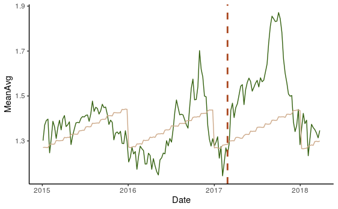

```r
plot1_bwd <- df2_bwd %>%
  group_by(Date) %>%
  summarize(
    MeanAvg=mean(AveragePrice),
    MeanAvg_hat=mean(AveragePrice_hat))%>%
    ggplot()+
    geom_line(aes(Date, MeanAvg),color = "#356211")+
    geom_line(aes(Date, MeanAvg_hat), color = "#cda989")+
    theme_classic()

plot1_bwd + geom_vline(aes(xintercept = as.numeric(Date[113])),
                   linetype = "dashed", size = 1,
                   color = "#AA471F")
```

### Ridge Regression

run ridge

```r
fit_ridge <- cv.glmnet(x1_train, y1_train, alpha = 0, nfolds = 100)
fit_ridge$lambda
```

```
  [1] 261.99201530 238.71736676 217.51037385 198.18735174 180.58093365
  [6] 164.53862122 149.92146362 136.60285400 124.46743295 113.41008927
 [11] 103.33504952  94.15504853  85.79057353  78.16917543  71.22484134
 [16]  64.89742274  59.13211457  53.87898050  49.09252037  44.73127617
 [21]  40.75747288  37.13669133  33.83757002  30.83153357  28.09254510
 [26]  25.59688082  23.32292448  21.25098015  19.36310165  17.64293707
 [31]  16.07558716  14.64747631  13.34623488  12.16059216  11.08027867
 [36]  10.09593725   9.19904201   8.38182448   7.63720629   6.95873793
 [41]   6.34054284   5.77726649   5.26403005   4.79638813   4.37029023
 [46]   3.98204569   3.62829173   3.30596429   3.01227154   2.74466964
 [51]   2.50084075   2.27867295   2.07624193   1.89179432   1.72373252
 [56]   1.57060088   1.43107302   1.30394044   1.18810197   1.08255426
 [61]   0.98638312   0.89875557   0.81891260   0.74616266   0.67987563
 [66]   0.61947735   0.56444469   0.51430098   0.46861190   0.42698171
 [71]   0.38904983   0.35448772   0.32299600   0.29430193   0.26815696
 [76]   0.24433463   0.22262862   0.20285090   0.18483019   0.16841038
 [81]   0.15344927   0.13981726   0.12739628   0.11607875   0.10576663
 [86]   0.09637061   0.08780931   0.08000858   0.07290084   0.06642453
 [91]   0.06052355   0.05514681   0.05024772   0.04578385   0.04171654
 [96]   0.03801056   0.03463380   0.03155703   0.02875359   0.02619920
```

Predict response

```r
yhat_train_ridge <- predict(fit_ridge, x1_train, s = fit_ridge$lambda)
yhat_test_ridge <- predict(fit_ridge, x1_test, s = fit_ridge$lambda)

mse_train_ridge = vector()
mse_test_ridge = vector()
mse_train_ridge <- mean((y1_train - yhat_train_ridge)^2)
mse_test_ridge <-mean((y1_test - yhat_test_ridge)^2)
for (i in 1:length(fit_ridge$lambda)) {
  mse_train_ridge[i] <- mean((y1_train - yhat_train_ridge)[,i]^2)
  mse_test_ridge[i] <- mean((y1_test - yhat_test_ridge)[,i]^2)
}
mse_train_ridge
```

```
  [1] 0.15012060 0.14949727 0.14943704 0.14937104 0.14929873 0.14921953
  [7] 0.14913279 0.14903783 0.14893387 0.14882010 0.14869563 0.14855948
 [13] 0.14841061 0.14824789 0.14807008 0.14787589 0.14766389 0.14743256
 [19] 0.14718028 0.14690530 0.14660576 0.14627969 0.14592501 0.14553950
 [25] 0.14512083 0.14466658 0.14417419 0.14364104 0.14306439 0.14244146
 [31] 0.14176939 0.14104530 0.14026632 0.13942957 0.13853228 0.13757171
 [37] 0.13654533 0.13545073 0.13428578 0.13304862 0.13173774 0.13035204
 [43] 0.12889089 0.12735415 0.12574233 0.12405657 0.12229876 0.12047153
 [49] 0.11857835 0.11662358 0.11461245 0.11255113 0.11044666 0.10830698
 [55] 0.10614085 0.10395775 0.10176778 0.09958151 0.09740983 0.09526373
 [61] 0.09315410 0.09109152 0.08908605 0.08714747 0.08528368 0.08350210
 [67] 0.08180885 0.08020874 0.07870524 0.07730049 0.07599533 0.07478934
 [73] 0.07368098 0.07266770 0.07174781 0.07091361 0.07016229 0.06948863
 [79] 0.06888726 0.06835268 0.06787937 0.06746188 0.06709495 0.06677351
 [85] 0.06649281 0.06624837 0.06603608 0.06585213 0.06569309 0.06555584
 [91] 0.06543771 0.06533589 0.06524842 0.06517338 0.06510903 0.06505385
 [97] 0.06500653 0.06496546 0.06493110 0.06490090
```

```r
mse_test_ridge
```

```
  [1] 0.1963519 0.1958176 0.1957660 0.1957095 0.1956476 0.1955798 0.1955056
  [8] 0.1954244 0.1953355 0.1952383 0.1951320 0.1950157 0.1948887 0.1947499
 [15] 0.1945983 0.1944329 0.1942524 0.1940556 0.1938411 0.1936076 0.1933534
 [22] 0.1930770 0.1927767 0.1924507 0.1920972 0.1917141 0.1912995 0.1908514
 [29] 0.1903675 0.1898458 0.1892842 0.1886804 0.1880324 0.1873380 0.1865955
 [36] 0.1858028 0.1849584 0.1840607 0.1831086 0.1821010 0.1810374 0.1799175
 [43] 0.1787414 0.1775098 0.1762238 0.1748851 0.1734960 0.1720594 0.1705790
 [50] 0.1690590 0.1675044 0.1659210 0.1643153 0.1626943 0.1610657 0.1594378
 [57] 0.1578192 0.1562189 0.1546458 0.1531091 0.1516174 0.1501791 0.1488020
 [64] 0.1474937 0.1462592 0.1451038 0.1440313 0.1430443 0.1421442 0.1413313
 [71] 0.1406046 0.1399621 0.1394009 0.1389173 0.1385057 0.1381629 0.1378829
 [78] 0.1376603 0.1374894 0.1373648 0.1372811 0.1372329 0.1372156 0.1372244
 [85] 0.1372551 0.1373040 0.1373676 0.1374427 0.1375268 0.1376173 0.1377152
 [92] 0.1378158 0.1379155 0.1380143 0.1381120 0.1382081 0.1383017 0.1383898
 [99] 0.1384754 0.1385589
```

```r
min(mse_train_ridge)
```

```
[1] 0.0649009
```

```r
min(mse_test_ridge)
```

```
[1] 0.1372156
```

```r
lambda_min_mse_train_ridge<- fit_ridge$lambda[which.min(mse_train_ridge)]
lambda_min_mse_test_ridge <-fit_ridge$lambda[which.min(mse_test_ridge)]
lambda_min_mse_train_ridge
```

```
[1] 0.0261992
```

```r
lambda_min_mse_test_ridge
```

```
[1] 0.1273963
```

```r
yhat_1<- predict(fit_ridge, x1_avo, s = lambda_min_mse_test_ridge)
```

Aggregate data into one dataframe

```r
p1<-avo %>%
  select(Date, AveragePrice)
p2<-cbind(p1, yhat_1)
```

## Plot

```r
p2 %>%
  group_by(Date)%>%
  summarise(meanpriced = mean(AveragePrice))
```

| Date | meanpriced |
| --- | --- |
| 2015-01-04 | 1.301296 |
| 2015-01-11 | 1.370648 |
| 2015-01-18 | 1.391111 |
| 2015-01-25 | 1.397130 |
| 2015-02-01 | 1.247037 |
| 2015-02-08 | 1.310463 |
| 2015-02-15 | 1.387593 |
| 2015-02-22 | 1.362685 |
| 2015-03-01 | 1.311019 |
| 2015-03-08 | 1.360093 |

[output cut: 159 more lines]

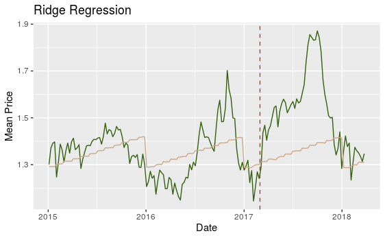

```r
names(p2)[3] <- "pre"
p2 %>%
  group_by(Date) %>%
  summarise(meanpriced = mean(AveragePrice),meanpre = mean(pre))%>%
  ggplot()+
  geom_line(mapping = aes(x=Date,
                           y=meanpriced), col = "#356211")+
  geom_line(mapping = aes(x=Date, y= meanpre), col = "#cda989")+
  geom_vline(xintercept=as.numeric(as.Date("2017-03-01")), col = "#AA471F", linetype = "dashed") +
  labs(title = "Ridge Regression",
       y = "Mean Price")
```

The ridge model is pretty much the same with lasso model, so we will see the difference between two models to see which model gives a more accurate prediction for our dataset after building a lasso model.

### Lasso Regression

Run lasso model

```r
lmodel <- glmnet(x1_train, y1_train, alpha = 1, nlambda = 100)
lmodel$lambda
```

```r
y1_train_hat <- predict(lmodel, s = lmodel$lambda, newx = x1_train)
y1_test_hat <- predict(lmodel, s = lmodel$lambda, newx = x1_test)

mse_train = vector()
mse_test = vector()

for (i in 1:length(lmodel$lambda)) {
  mse_train[i] <- mean((y1_train - y1_train_hat)[,i]^2)
  mse_test[i] <- mean((y1_test - y1_test_hat)[,i]^2)
}

min(mse_train)
min(mse_test)
```

Check the minimun lambda for the train and test dataset

```r
lambda_min_mse_train_lasso<- lmodel$lambda[which.min(mse_train)]
lambda_min_mse_test_lasso <-lmodel$lambda[which.min(mse_test)]
lambda_min_mse_train_lasso
lambda_min_mse_test_lasso
```

```r
set.seed(1)
cv.out = cv.glmnet(x1_train, y1_train, alpha = 1)
## plot the lambda
plot(cv.out)
##check the best lambda
bestlam = cv.out$lambda.min
bestlam ## the best lamdba for training dataset is same as lambda_min_mse_train
```

```r
f1coef<-coef(lmodel, s = lambda_min_mse_test_lasso)
f1coef
```

Create a new formula for new predictors(eliminate the uncorrelated predictors)

```r
f2 <- as.formula(AveragePrice ~ month + type_conventional + type_organic +
                   PLU4046 + PLU4770 + LargeBags + XLargeBags +
                   Area_NewEngland + Area_Southeast + Area_Mideast +
                   Area_RockyMountain + Area_GreatLakes +
                   Area_Southwest + Area_Plains)
x2_train <- model.matrix(f2,avo_train)[,-1]
x2_test <- model.matrix(f2, avo_test)[,-1]
```

Run lasso model again with new predictors

```r
lmodel2 <- glmnet(x2_train, y1_train, alpha = 1, nlambda = 100)
```

Predict response with new predictors

```r
y2_train_hat <- predict(lmodel2, s = lmodel2$lambda, newx = x2_train)
y2_test_hat <- predict(lmodel2, s = lmodel2$lambda, newx = x2_test)
```

```r
mse_train1 = vector()
mse_test1 = vector()

for (i in 1:length(lmodel2$lambda)) {
  mse_train1[i] <- mean((y1_train - y2_train_hat)[,i]^2)
  mse_test1[i] <- mean((y1_test - y2_test_hat)[,i]^2)
}

min(mse_train1)
min(mse_test1)
```

Check again with the new minimum lambda for the train and test dataset

```r
lambda_min_mse_train1<- lmodel2$lambda[which.min(mse_train1)]
lambda_min_mse_test1 <-lmodel2$lambda[which.min(mse_test1)]
lambda_min_mse_train1
lambda_min_mse_test1
```

Check coefficients for f2, there is no more uncorrelated predictors in our model.

```r
f2coef<-coef(lmodel2, s = lambda_min_mse_test1)
f2coef
```

Since the second model have the lowest test MSE, we decided to use “lmodel2” to make the final prediction.

```r
x2_avo <- model.matrix(f2, avo)[,-1]
y2_avo_min_lambda_hat <- predict(lmodel2, s = lambda_min_mse_test1, newx = x2_avo)
class(y2_avo_min_lambda_hat)
```

Aggregate data into one dataframe for the first model prediction

```r
df1<-avo %>%
  select(Date, AveragePrice)
df2<-cbind(df1, y2_avo_min_lambda_hat)

names(df2)[3]<-"AveragePrice_hat"
```

Plot the actual average price and the predictive average price

```r
head(df2)
class(df2$Date)
plot1 <- df2 %>%
  group_by(Date) %>%
  summarize(
    MeanAvg=mean(AveragePrice),
    MeanAvg_hat=mean(AveragePrice_hat)) %>%
  ggplot()+
  geom_line(aes(Date, MeanAvg),color = "#356211")+
  geom_line(aes(Date, MeanAvg_hat), color = "#cda989")+
  theme_classic()

plot1 + geom_vline(aes(xintercept = as.numeric(Date[113])),
                   linetype = "dashed", size = 1,
                   color = "#AA471F")
```

### Decision Tree

```r
fit.tree <- rpart(f1,
                  avo_train,
                  control = rpart.control(cp = 0.001))

par(xpd = TRUE)
plot(fit.tree, compress=TRUE)
text(fit.tree, use.n=TRUE)
rpart.plot(fit.tree, type = 1)
```

```r
yhat.train.tree <- predict(fit.tree, avo_train)
mse.train.tree <- mean((avo_train$AveragePrice - yhat.train.tree)^2)
mse.train.tree
```

```r
yhat.test.tree <- predict(fit.tree, avo_test)
mse.test.tree <- mean((avo_test$AveragePrice - yhat.test.tree)^2)
mse.test.tree
```

### Regression Tree

```r
tree.avo =tree(f1, avo_train)
summary(tree.avo)
```

```r
cv.avo =cv.tree(tree.avo)

prune.avo =prune.tree(tree.avo,best =5)
plot(prune.avo)
text(prune.avo,pretty =0)
```

```r
yhat <- predict(tree.avo, newdata = avo_test)
mse_regreTree_test <- mean((yhat - avo_test$AveragePrice)^2)
mse_regreTree_test
```

### Bagging

```r
set.seed (1)
bag.avo =randomForest(f1, data = avo_train,
                           mtry = 19, importance =TRUE)
bag.avo
```

```r
yhat.bag = predict (bag.avo, newdata = avo_test)
plot(yhat.bag, avo_test$AveragePrice, main = "Scatter Plot for Bagging",
     xlab = "Prediction price in test set", ylab = "Average price in test set",
     col = "#bdcc64")
abline (0,1)

mse_bag_test <- mean((yhat.bag - avo_test$AveragePrice)^2)
mse_bag_test
```

### Random Forests

Building the model first:

```r
fit_rf <- randomForest(f1,
                       avo_train,
                       ntree=300,
                       do.trace=F)
varImpPlot(fit_rf)
```

Predicting our y_hats for train and for test data:

```r
yhat_rf_train <- predict(fit_rf, avo_train)
yhat_rf_test <- predict(fit_rf, avo_test)
```

Calculating MSE for both train and test:

```r
mse_rf_train <- mean((yhat_rf_train - y1_train) ^ 2)
mse_rf_test <- mean((yhat_rf_test - y1_test)^2)

print(mse_rf_train)
print(mse_rf_test)
```

Plotting actual prices and predicted prices on one plot: Have to prepare data to use it for the plot first by creating a dataframe with Date, AveragePrice and Predicted Price (y_hat) for both train and test:

```r
avo %>%
  select(Date, AveragePrice) -> plot_rf_full

yhat_rf_full <- c(yhat_rf_train,yhat_rf_test )

cbind(plot_rf_full, yhat_rf_full) -> plot_rf_full1
```

```r
plot_rf_full1 %>%
  group_by(Date) %>%
  summarise(mean_y = mean(AveragePrice),
            mean_yhat = mean(yhat_rf_full)) %>%
  ggplot() +
  geom_line(aes(x = Date, y = mean_y), col = "#356211") +
  geom_line(aes(x = Date, y = mean_yhat), col = "#cda989") -> rf_graph

rf_graph + geom_vline(aes(xintercept = as.numeric(Date[113])),
                   linetype = "dashed", size = 1,
                   color = "#AA471F") +
  labs(title = "Random Forest",
       y = "Mean Price")
```

### Boosting

```r
boostingcv <- gbm(f1,
                  data = avo_train,
                  distribution = "gaussian",
                  n.trees = 150,
                  interaction.depth = 4,
                  cv.folds = 10,
                  shrinkage = 0.1)
relative.influence(boostingcv)

yhat_btree <- predict(boostingcv, avo_train, n.trees = 150)
mse_btree <- mean((yhat_btree - y1_train) ^ 2)
print(mse_btree)
```

```r
yhat_btree_test <- predict(boostingcv, avo_test, n.trees = 150)
mse_btree_test <- mean((yhat_btree_test - y1_test) ^ 2)
print(mse_btree_test)
```

```r
avo_train$prediction_btree <- yhat_btree
avo_test$prediction_btree <- yhat_btree_test

avo_plot <- rbind(avo_train, avo_test)
```

```r
btree_plot <- avo_plot %>%
  group_by(Date) %>%
  summarise(meanAvg = mean(AveragePrice),
            meanAvg_hat = mean(prediction_btree)) %>%
  ggplot() +
  geom_line(aes(Date, meanAvg), col = "#356211") +
  geom_line(aes(Date, meanAvg_hat), col = "#cda989") +
  labs(title = "Boosting",
       y = "Mean Price") +
  theme_clean()

btree_plot +
  geom_vline(aes(xintercept = as.numeric(Date[113])),
             linetype = "dashed", size = 1, col = "#AA471F")
```

### Lasso with a New Variable

```r
ds1 <- read_csv("avocado3.csv")
glimpse(ds1)
```

The new dataset called `avocado3` is the dataset that we created based on the original avocado dataset. We create two more columns called “NewPrice” and “NewPrice2” which was based on the previous price that we have as “AveragePrice”. The NewPrice was come from the AveragePrice of one row above and the “NewPrice2” was from the AveragePrice of two rows above. We are going to add these two columns as new variables to do a more accurate prediction for our time-series based dataset.

```r
ds1 <- ds1 %>%
  group_by(type, region) %>%
  select(X1, year, Date, type, region, everything()) %>%
  arrange(Date)

ds1 <- ds1 %>%
  group_by(type, region) %>%
  select(X1, year, Date, type, region, everything()) %>%
  arrange(Date)

colName <- names(ds1)
colName[1] <- "ID"
names(ds1) <- colName

ds1$ID <- seq(nrow(ds1))

ds1$month <- month(ds1$Date)
ds1 <- ds1 %>%
  select(ID, year, month, everything())

ds1New <- dummy_cols(ds1, select_columns = "type") %>%
  select(ID, year, month, region, type_conventional, type_organic,
         everything(), -type)

ds1New$other_PLU <- ds1New$`Total Volume` - ds1New$`4046` - ds1New$`4225` - ds1New$`4770`

ds1New <- ds1New %>%
  select(1:3, Date, everything())

uniqueRegion <- unique(ds1New$region)
uniqueRegion <- as.data.frame(uniqueRegion)
uniqueRegion$Area <- NA
uniqueRegion$Area[1] <- "NewEngland"
uniqueRegion$Area[2] <- "Southeast"
uniqueRegion$Area[3] <- "Mideast"
uniqueRegion$Area[4] <- "RockyMountain"
uniqueRegion$Area[5] <- "NewEngland"
uniqueRegion$Area[6] <- "Mideast"
uniqueRegion$Area[7] <- "FarWest"
uniqueRegion$Area[8] <- "Southeast"
uniqueRegion$Area[9] <- "GreatLakes"
uniqueRegion$Area[10] <- "GreatLakes"
uniqueRegion$Area[11] <- "GreatLakes"
uniqueRegion$Area[12] <- "Southwest"
uniqueRegion$Area[13] <- "RockyMountain"
uniqueRegion$Area[14] <- "GreatLakes"
uniqueRegion$Area[15] <- "GreatLakes"
uniqueRegion$Area[16] <- "GreatLakes"
uniqueRegion$Area[17] <- "Mideast"
uniqueRegion$Area[18] <- "NewEngland"
uniqueRegion$Area[19] <- "Southeast"
uniqueRegion$Area[20] <- "GreatLakes"
uniqueRegion$Area[21] <- "Southeast"
uniqueRegion$Area[22] <- "FarWest"
uniqueRegion$Area[23] <- "FarWest"
uniqueRegion$Area[24] <- "Southeast"
uniqueRegion$Area[25] <- "Southeast"
uniqueRegion$Area[26] <- "Southeast"
uniqueRegion$Area[27] <- "Southeast"
uniqueRegion$Area[28] <- "Southeast"
uniqueRegion$Area[29] <- "Mideast"
uniqueRegion$Area[30] <- "NewEngland"
uniqueRegion$Area[31] <- "NewEngland"
uniqueRegion$Area[32] <- "Southeast"
uniqueRegion$Area[33] <- "Mideast"
uniqueRegion$Area[34] <- "Southwest"
uniqueRegion$Area[35] <- "Mideast"
uniqueRegion$Area[36] <- "Plains"
uniqueRegion$Area[37] <- "FarWest"
uniqueRegion$Area[38] <- "Southeast"
uniqueRegion$Area[39] <- "Southeast"
uniqueRegion$Area[40] <- "Southeast"
uniqueRegion$Area[41] <- "FarWest"
uniqueRegion$Area[42] <- "FarWest"
uniqueRegion$Area[43] <- "FarWest"
uniqueRegion$Area[44] <- "FarWest"
uniqueRegion$Area[45] <- "Southeast"
uniqueRegion$Area[46] <- "Southeast"
uniqueRegion$Area[47] <- "Southeast"
uniqueRegion$Area[48] <- "FarWest"
uniqueRegion$Area[49] <- "Plains"
uniqueRegion$Area[50] <- "Mideast"
uniqueRegion$Area[51] <- "Southeast"
uniqueRegion$Area[52] <- "TotalUS"
uniqueRegion$Area[53] <- "FarWest"
uniqueRegion$Area[54] <- "Southwest"
names(uniqueRegion)[1] <- "region"

avo <- ds1New %>%
  left_join(uniqueRegion, by = "region") %>%
  select(1:5, Area, everything())
avo <- dummy_cols(avo, select_columns = "Area")

names(avo)[10] <- "TotalVolume"
names(avo)[14] <- "TotalBags"
names(avo)[15] <- "SmallBags"
names(avo)[16] <- "LargeBags"
names(avo)[17] <- "XLargeBags"
names(avo)[11] <- "PLU4046"
names(avo)[12] <- "PLU4225"
names(avo)[13] <- "PLU4770"

set.seed(1234)
avo_train <- avo %>% filter(as.Date(Date) < "2017-03-01")
avo_train %>%
  filter(year == 2017, month == 2)
avo_test <- avo %>% filter(as.Date(Date) >= "2017-03-01")
avo_test %>%
  filter(year == 2018, month == 3)
```

pre model

```r
f2 <- as.formula(AveragePrice ~ month +type_conventional + type_organic + TotalVolume +
                   PLU4046 + PLU4770 + PLU4225 + SmallBags + LargeBags + XLargeBags +
                   + Area_NewEngland + Area_Southeast
                 + Area_Mideast + Area_RockyMountain
                 + Area_FarWest
                 + Area_GreatLakes + Area_Southwest
                 + Area_Plains + Area_TotalUS + NewPrice + NewPrice2)

x1_train <- model.matrix(f2,avo_train)[,-1]
y1_train <- avo_train$AveragePrice
x1_test <- model.matrix(f2, avo_test)[,-1]
y1_test <- avo_test$AveragePrice
date_test <- avo_test$Date
x1_avo <- model.matrix(f2, avo)[,-1]
```

Run lasso

```r
lmodel <- glmnet(x1_train, y1_train, alpha = 1, nlambda = 100)
lmodel$lambda
```

Predict response

```r
y1_train_hat <- predict(lmodel, s = lmodel$lambda, newx = x1_train)
y1_test_hat <- predict(lmodel, s = lmodel$lambda, newx = x1_test)
length(y1_test_hat)
mse_train = vector()
mse_test = vector()

for (i in 1:length(lmodel$lambda)) {
  mse_train[i] <- mean((y1_train - y1_train_hat)[,i]^2)
  mse_test[i] <- mean((y1_test - y1_test_hat)[,i]^2)
}
mse_train
mse_test

min(mse_test)
```

```r
lambda_min_mse_train<- lmodel$lambda[which.min(mse_train)]
lambda_min_mse_test <-lmodel$lambda[which.min(mse_test)]
lambda_min_mse_train
lambda_min_mse_test
```

Using Cross-validation fucntion to find the best lambda

```r
set.seed(1)
cv.out = cv.glmnet(x1_train, y1_train, alpha = 1)
```

Plot the lambda

```r
plot(cv.out,
     xlab = "Log(lambda)")
```

Check the best lambda

```r
bestlam = cv.out$lambda.min
bestlam ## the best lamdba for training dataset is same as lambda_min_mse_train
```

Create a new formula for new predictors(eliminate the uncorrelated predictors)

```r
f3 <- as.formula(AveragePrice ~ month + type_conventional + type_organic +
                   PLU4046 + PLU4770 + PLU4225 + LargeBags + XLargeBags +
                   Area_NewEngland + Area_Southeast + Area_Mideast +
                   Area_RockyMountain + Area_GreatLakes +
                   Area_Southwest + Area_Plains)
x2_train <- model.matrix(f3,avo_train)[,-1]
x2_test <- model.matrix(f3, avo_test)[,-1]
```

Run lasso model again with new predictors

```r
lmodel2 <- glmnet(x2_train, y1_train, alpha = 1, nlambda = 100)
```

Predict response with new predictors

```r
y2_train_hat <- predict(lmodel2, s = lmodel2$lambda, newx = x2_train)
y2_test_hat <- predict(lmodel2, s = lmodel2$lambda, newx = x2_test)
```

Compute MES again with new predictors. The results shows the taining data MSE is increased when eliminate the predictors which don’t have correlation but the test data MSE still keep the same.

```r
mse_train1 = vector()
mse_test1 = vector()

for (i in 1:length(lmodel2$lambda)) {
  mse_train1[i] <- mean((y1_train - y2_train_hat)[,i]^2)
  mse_test1[i] <- mean((y1_test - y2_test_hat)[,i]^2)
}
mse_train1
mse_test1
min(mse_train1)
min(mse_test1)

lambda_min_mse_train1<- lmodel2$lambda[which.min(mse_train1)]
lambda_min_mse_test1 <-lmodel2$lambda[which.min(mse_test1)]
lambda_min_mse_train1
lambda_min_mse_test1
```

Check coefficients for f2 and f3 model

```r
f2coef<-coef(lmodel, s = lambda_min_mse_test)
f3coef<-coef(lmodel2, s = lambda_min_mse_test1)
f2coef
f3coef
```

Since the second model have the training MSE increased, the ideal model is still the first “lmodel”, so we decide to use “lmodel” to run the prediction

```r
y1_avo_min_lambda_hat <- predict(lmodel, s = lambda_min_mse_test, newx = x1_avo)
class(y1_avo_min_lambda_hat)
```

Aggregate data into one dataframe for the first model prediction

```r
df2<-avo %>%
  select(Date, AveragePrice)
df3<-cbind(df2, y1_avo_min_lambda_hat)
colnames(df3)

names(df3)[3]<-"AveragePrice_hat"
```

Plot the actual average price and the predictive average price

```r
head(df3)
class(df3$Date)
 df3 %>%
  group_by(Date) %>%
  summarise(meanpriced = mean(AveragePrice),meanpre = mean(AveragePrice_hat))%>%
  ggplot()+
  geom_line(mapping = aes(x=Date,
                           y=meanpriced), col = "#356211")+
  geom_line(mapping = aes(x=Date, y= meanpre), col = "#cda989")+
  geom_vline(xintercept=as.numeric(as.Date("2017-03-01")), col = "#AA471F", linetype = "dashed", size = 1)+
   labs(title = "Lasso with new variables",
        y = "Mean Price") +
   theme_classic()
```

### Lasso with a previous day prediction as a variable

Because we are working with time series dataset, it is reasonable to assume that the previous day price plays a big part in predicting a next day price. Therefore, we have tried to create a code that would predict one day price and use it as a predictor for the next day price.

Let’s make a new dataframe with lagged 1 day price as an additional variable, and change it to zero for test data (as in real life we would not know the previous day price):

```r
avo_ts <- avo %>%
          mutate(lag1_y = lag(AveragePrice))

dim(avo_ts)
avo_ts <- drop_na(avo_ts)
dim(avo_ts)

avo_train_ts <- avo_ts[1:12202, ]
avo_test_ts <- avo_ts[12203:18248, ]
dim(avo_test_ts)

avo_test_ts[2:6046,"lag1_y"] <- 0
```

Running a loop to predict each day using previous day prediction:

```r
f_ts <- as.formula(AveragePrice ~ lag1_y + month + type_conventional + type_organic +
                           PLU4046 + PLU4770 + PLU4225 + LargeBags + XLargeBags +
                           Area_NewEngland + Area_Southeast + Area_Mideast +
                           Area_RockyMountain + Area_GreatLakes +
                           Area_Southwest + Area_Plains)


y_hat_ts_test_f <- avo_test_ts[1,"lag1_y"]
avo_ts1 <- avo_ts
lambda_min_test <- 0.001570601 #the min lambda from lasso model above
check_ts <- vector()
for (i in 1:6045) {
  avo_train_ts <- avo_ts1[1:(12203+i), ]
  avo_test_ts <- avo_ts1[(12204+i):18248, ]

  x_ts_train <- model.matrix(f_ts,avo_train_ts)[,-1]
  x_ts_test <- model.matrix(f_ts, avo_test_ts)[,-1]

  y_ts_train <- avo_train_ts$AveragePrice
  y_ts_test <- avo_test_ts$AveragePrice

  lmodel_ts <- glmnet(x_ts_train, y_ts_train, alpha = 1, nlambda = 100)

  y_ts_train_hat <- predict(lmodel_ts, s = lambda_min_test, newx = x_ts_train)
  y_ts_test_hat <- predict(lmodel_ts, s = lambda_min_test, newx = x_ts_test)
  y_hat_ts_test_f <- c(y_hat_ts_test_f, y_ts_test_hat[1])
  (length(y_hat_ts_test_f))
  avo_ts1[(12204+i), "lag1_y"] <- y_ts_test_hat[1]

}
```

The loop gives back an error, which we, unfortunately, could not resolve. (Also because this loop takes long time to run).

However, it somehow worked to gather prediction based on previous day prediction as variable. We can see it in here:

```r
length(y_hat_ts_test_f)
y_hat_ts_test_f <- unlist(y_hat_ts_test_f)
```

```r
y_hat_ts_test_f <- c(y_hat_ts_test_f, mean(y_hat_ts_test_f), mean(y_hat_ts_test_f))
length(y_hat_ts_test_f)
```

We need to also readjust test data because of the loop changes:

```r
avo_test_ts <- avo_ts[12203:18248,]
y_ts_test <- avo_test_ts$AveragePrice
```

We now can calculate MSE:

```r
mse_ts_test_f <- mean((y_ts_test - y_hat_ts_test_f)^2)
print(mse_ts_test_f)
```

Let’s see if plot can show the difference.

Need to select and prepare data for the plot first:

```r
avo %>%
  select(Date, AveragePrice) -> plot_ts_full
plot_ts_full <- plot_ts_full[2:nrow(plot_ts_full),]

y_hat_train_ts <-  y_ts_train_hat[1:12202,]
y_hat_ts_full <- c(y_hat_train_ts, y_hat_ts_test_f )

plot_ts <- cbind(plot_ts_full, y_hat_ts_full)
```

Plot:

```r
plot_ts %>%
  group_by(Date) %>%
  summarise(mean_y = mean(AveragePrice),
            mean_yhat = mean(y_hat_ts_full)) %>%
  ggplot() +
  geom_line(aes(x = Date, y = mean_y), col = "#356211") +
  geom_line(aes(x = Date, y = mean_yhat), col = "#cda989") -> ts_graph

ts_graph + geom_vline(aes(xintercept = as.numeric(Date[113])),
                   linetype = "dashed", size = 1,
                   color = "#AA471F") +
  labs(title = "Lasso with Loop",
       y = "Mean Price")
```

## Result

### Key to choose the best model

### The best one

### Challenges

## Conclusions

### Influential Predictors

### Reflections

### References